# Ejercicios

Deysy Condor Melo

July 2, 2021

# PARTE N°1

### 5. A partir de los vectores grupo y nota definidos.

#### a) Suma las notas de los 10 primeros alumnos del vector

*Cargamos los datos*

```r
load("~/9 Ciclo/Programación en R/Ejercicios/ei1012-1516-la-s1-datos.RData")
```

*Llamamos a las librerias*

```r
# library(tidyverse)
library(dplyr)
head(nota,10)
```

```
##  [1] 4.9 5.4 5.2 6.8 5.0 6.2 4.4 4.1 4.3 5.5
```

```r
sum(head(nota,10))
```

```
## [1] 51.8
```

#### b) ¿Cuantos alumnos hay del grupo C?

```r
sum(grupo== "C")
```

```
## [1] 39
```

#### c) ¿Cuantos alumnos han aprobado?

```r
sum(nota>=5.5)
```

```
## [1] 73
```

#### d) ¿Cuantos alumnos del grupo B han aprobado?

```r
df <- data.frame(grupo,nota)
df02<- as_tibble(df)
nrow (filter(df02, grupo == "B", nota >= 5.5))
```

```
## [1] 9
```

#### e) ¿Que porcentaje de alumnos del grupo C han aprobado?

```r
notasB <- nota [which( grupo == "B" )] # notas de los alumnos del grupo B
aprobadosC <- nrow (filter(df02, grupo == "C", nota >= 5.5))

which( grupo == "C" )
```

```
##  [1]  10  19  20  22  23  30  31  34  50  55  58  66  68  69  70  75  79  81  89
## [20]  91  94 105 112 118 127 128 130 131 133 135 147 160 164 168 171 172 173 180
## [39] 191
```

```r
notasC <- nota [which( grupo == "C" )] # notas de los alumnos del grupo C
which(notasB >= 5.5)
```

```
## [1]  3  4 10 12 13 18 19 20 23
```

```r
NaprobadosC <- length(which(notasB >= 5.5)) # N° alumnos C aprobados
TotalC <- length(which( grupo == "C") ) # N° total alumnos C
porc <- (aprobadosC/TotalC)*100
print(porc)
```

```
## [1] 51.28205
```

#### f) ¿De que grupos son la maxima y minima notas de toda la muestra?

```r
Y<- nota
max(Y) -> Z
Z
```

```
## [1] 7.7
```

```r
min(Y) -> R
R
```

```
## [1] 1.7
```

```r
A <- grupo [which( nota == Z )]
A
```

```
## [1] "E"
```

```r
B <- grupo [which( nota == R )]
B
```

```
## [1] "B"
```

#### g) Nota media de los alumnos de grupo A y B, juntos, considerando sólo a los que han aprobado.

```r
notasA <- nota [which(grupo == "A")] # notas de los alumnos del grupo A
AprobadasA <- notasA[which(notasA >= 5.5)] # Notas aprobadas de A

notasB <- nota [which(grupo == "B")] # notas de los alumnos del grupo B
AprobadasB <- notasB[which(notasB >= 5.5)] # Notas aprobadas de B

c <- c(AprobadasA, AprobadasB)

mean(c)
```

```
## [1] 6.109091
```

### 6. Calcula el percentil 66 de las notas de todos los alumnos, y también de los alumnos del grupo C.

#### a) Todos los alumnos

```r
perc <- df$nota
quantile(perc, c(.66))
```

```
## 66%
## 5.5
```

#### b) Alumnos del grupo C

```r
GC <- filter(df02, grupo == "C")
GC
```

```
## # A tibble: 39 x 2
##    grupo  nota
##    <chr> <dbl>
##  1 C       5.5
##  2 C       4.8
##  3 C       3.4
##  4 C       6
##  5 C       5.9
##  6 C       4.4
##  7 C       5.8
##  8 C       6.2
##  9 C       6.2
## 10 C       5.6
## # ... with 29 more rows
```

```r
perc2 <- GC$nota
quantile(perc2, c(.66))
```

```
##   66%
## 5.808
```

### 7. ¿Que porcentaje, del total de alumnos, tiene una nota menor o igual que la suya? ¿Y qué porcentaje tiene una nota mayor o igual que la suya?.

```r
x<-c(nota)
A <- which(x <= 4.9)
C <- length(A)
A
```

```
##  [1]   1   7   8   9  12  16  19  20  21  29  30  32  37  39  40  42  44  45  46
## [20]  47  49  52  54  57  59  60  62  64  66  67  69  74  75  76  77  80  82  84
## [39]  85  87  89  90  92  97  98  99 101 102 104 106 107 111 112 113 115 117 123
## [58] 125 127 129 130 133 134 135 136 141 142 146 149 152 154 155 156 158 159 160
## [77] 161 164 165 167 168 173 174 175 178 179 183 185 190 192
```

```r
B <- length(nota)
(C*100/B)
```

```
## [1] 46.875
```

```r
x<-c(nota)
A <- which(x >= 4.9)
C <- length(A)
A
```

```
##   [1]   1   2   3   4   5   6  10  11  13  14  15  17  18  22  23  24  25  26
##  [19]  27  28  31  33  34  35  36  38  41  42  43  48  50  51  53  55  56  58
##  [37]  59  61  63  65  68  70  71  72  73  78  79  81  83  86  88  90  91  93
##  [55]  94  95  96 100 103 105 106 108 109 110 114 116 118 119 120 121 122 124
##  [73] 126 128 131 132 137 138 139 140 141 143 144 145 147 148 150 151 153 157
##  [91] 162 163 166 169 170 171 172 176 177 180 181 182 184 186 187 188 189 191
```

```r
B <- length(nota)
(C*100/B)
```

```
## [1] 56.25
```

### 8. Realiza el grafico de diagramas de caja de las notas de cada grupo, para poder comparar el nivel de cada uno de ellos.

```r
N <- c(nota)
N
```

```
##   [1] 4.9 5.4 5.2 6.8 5.0 6.2 4.4 4.1 4.3 5.5 5.5 4.8 6.4 6.8 5.5 4.7 5.2 6.4
##  [19] 4.8 3.4 4.7 6.0 5.9 5.4 5.3 5.6 6.9 5.6 4.2 4.4 5.8 4.8 6.1 6.2 6.6 5.2
##  [37] 4.6 5.0 2.5 4.0 5.6 4.9 5.4 3.9 4.2 4.7 4.2 5.4 3.7 6.2 5.9 3.7 5.8 2.7
##  [55] 5.6 5.0 2.6 5.0 4.9 3.4 5.9 4.3 6.1 4.5 5.5 3.2 3.2 6.4 4.4 6.0 5.0 5.4
##  [73] 7.0 3.8 4.2 4.7 4.7 5.3 6.8 4.0 7.2 4.8 6.0 4.1 4.5 5.8 2.9 5.0 4.6 4.9
##  [91] 6.8 4.2 6.9 5.7 5.7 6.4 4.4 4.2 4.5 5.8 4.3 3.7 7.4 3.9 5.2 4.9 3.6 5.5
## [109] 6.0 5.0 4.1 4.5 3.1 5.4 4.5 5.3 4.7 6.1 5.2 7.7 5.3 5.0 4.0 5.2 4.0 5.5
## [127] 4.0 5.4 4.6 3.4 6.2 5.7 3.8 4.8 4.0 4.4 5.5 5.9 5.9 5.7 4.9 1.7 5.5 5.9
## [145] 5.5 3.8 5.5 6.0 3.5 5.5 7.5 3.4 5.8 4.7 3.6 4.1 5.0 4.6 3.6 4.7 4.1 5.7
## [163] 5.9 4.7 3.2 5.5 3.0 4.5 5.5 5.9 5.6 6.0 4.4 3.7 4.4 6.8 6.1 4.7 4.2 6.2
## [181] 5.2 5.1 2.9 6.5 4.2 5.4 5.9 6.2 6.3 4.8 5.6 2.9
```

```r
A <- nota [which( grupo == "A" )]
A
```

```
##  [1] 5.4 4.1 5.2 4.7 5.6 4.1 4.3 5.5 4.1 4.5 4.0 4.4 4.8 2.9
```

```r
B <- nota [which( grupo == "B" )]
B
```

```
##  [1] 4.9 5.0 6.4 6.4 4.2 4.2 5.0 4.3 4.5 5.5 4.5 5.8 7.4 3.9 4.6 4.8 1.7 6.0 5.9
## [20] 6.8 4.7 5.4 5.9
```

```r
C <- nota [which( grupo == "C" )]
C
```

```
##  [1] 5.5 4.8 3.4 6.0 5.9 4.4 5.8 6.2 6.2 5.6 5.0 3.2 6.4 4.4 6.0 4.2 6.8 7.2 4.6
## [20] 6.8 5.7 5.2 4.5 6.1 4.0 5.4 3.4 6.2 3.8 4.0 5.5 4.7 4.7 4.5 5.6 6.0 4.4 6.2
## [39] 5.6
```

```r
D <- nota [which( grupo == "D" )]
D
```

```
##  [1] 6.8 6.2 4.4 4.3 5.5 5.4 5.3 6.1 2.5 4.0 5.6 4.2 3.7 3.7 2.6 3.4 6.1 3.2 5.4
## [20] 3.8 4.7 4.0 6.0 4.9 6.4 4.4 4.2 5.8 3.7 4.9 5.4 5.3 4.7 5.0 5.7 5.5 5.9 3.5
## [39] 5.5 5.8 4.7 4.1 4.6 3.6 4.1 5.7 5.9 5.5 3.7 4.4 6.1 5.1 2.9 4.2
```

```r
E <- nota [which( grupo == "E" )]
E
```

```
##  [1] 5.2 4.8 6.8 5.5 4.7 5.6 6.9 4.8 6.6 5.2 4.6 5.0 4.9 5.4 3.9 4.7 5.4 5.9 5.8
## [20] 2.7 4.9 5.9 5.0 7.0 4.7 5.3 4.8 2.9 5.0 4.2 6.9 5.7 4.5 3.6 6.0 5.0 3.1 5.2
## [39] 7.7 5.3 5.2 4.0 5.5 5.9 5.7 4.9 5.5 5.9 5.5 3.8 7.5 3.4 3.6 5.0 3.2 3.0 5.5
## [58] 4.2 5.2 6.5 6.2 6.3
```

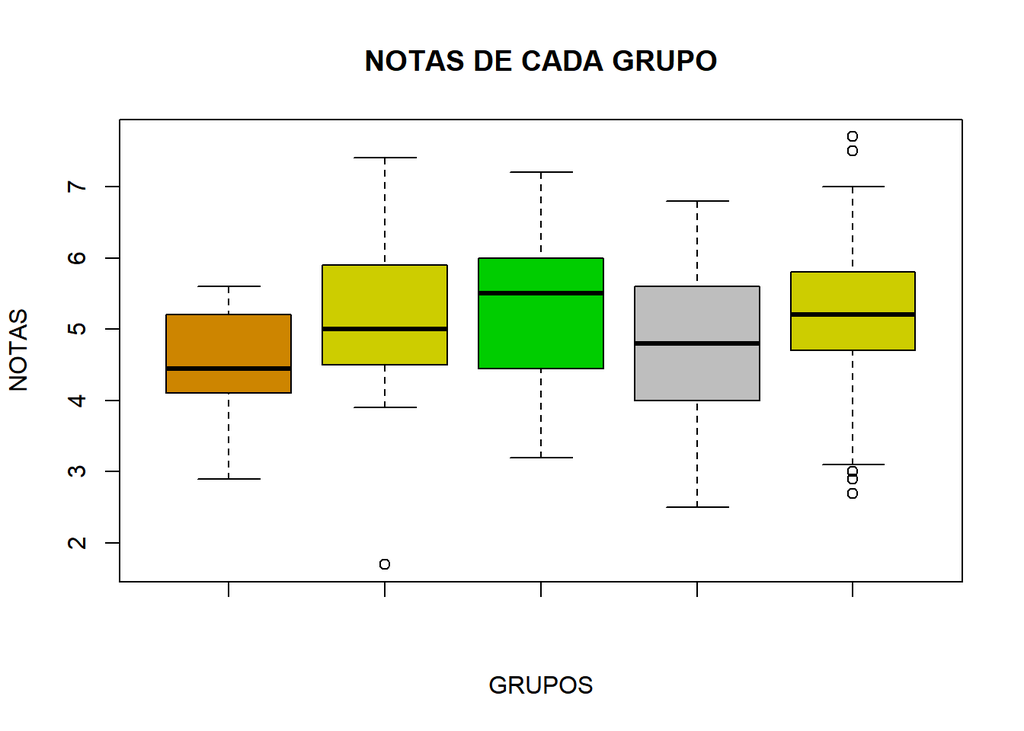

```r
boxplot (A, B, C, D, E, main = "NOTAS DE CADA GRUPO",
         xlab = "GRUPOS", ylab = "NOTAS",
         col = c("orange3", "yellow3", "green3", "grey", "yellow3"))
```

### 9. Si la variable conc recoge la concentración de plomo (en ppm) en el aire de cierta zona durante un dia completo.

#### a) ¿Cuál ha sido la concentraci?n maxima?

```r
max(conc)
```

```
## [1] 47.34
```

#### b) ¿En cuántos de los muestreos se ha superado la concentraci?n de 40.0 ppm?

```r
sum(conc > 40.0)
```

```
## [1] 61
```

#### c) ¿Cuál ha sido la concentraci?n media del d?a?

```r
mean(conc)
```

```
## [1] 24.07229
```

#### d) ¿Cuáles fueron las 10 mediciones más bajas del día?

```r
m<-sort(conc)
head(m<-sort(conc), 10)
```

```
##  [1] 0.93 1.07 1.77 2.03 2.58 2.73 2.75 2.88 2.88 2.91
```

```r
hora<-seq(as.POSIXct("00:00", format="%H:%M"),
          as.POSIXct("23:59", format="%H:%M"), by="5 min")
h_conc<-data.frame(hora=hora,Medida=conc)
h_conc[max(h_conc$Medida),]
```

```
##                   hora Medida
## 47 2021-07-10 03:50:00  12.91
```

```r
h_max<-h_conc %>% select(Medida) %>% summarise(max(Medida))
```